```python
import umap
import umap.plot
from sklearn.datasets import load_digits
import matplotlib.pyplot as plt
import matplotlib as mpl
import numpy as np
from sklearn.metrics import calinski_harabasz_score as CH
from sklearn.metrics import silhouette_score as ASW
from scipy.optimize import brentq
from scipy.interpolate import make_interp_spline
from sklearn.linear_model import LinearRegression as LinReg
```

```python
# initialize colors
from pride_colors import pride_colors_matplotlib
from matplotlib import cm
BI = pride_colors_matplotlib(flag='bi')
BP = cm.get_cmap("PuRd")
NW_purple = '#4E2A84'
```

# Trying Out UMAP with MNIST

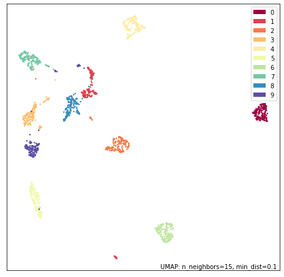

```python
# check installation - use the demo example
digits = load_digits()
mapper = umap.UMAP(n_neighbors=15, spread=0.5).fit(digits.data)
umap.plot.points(mapper, labels=digits.target)
```

```
Input dimensions: (1797, 64)
Output dimensions: (1797, 2)
```

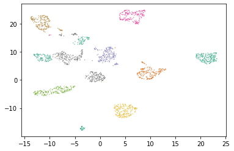

```python
# try it another way
Y = umap.UMAP(min_dist=0.5, spread=2).fit_transform(digits.data)
print("Input dimensions:", digits.data.shape)
print("Output dimensions:", Y.shape)
plt.scatter(Y[:,0], Y[:,1], c=digits.target, s=0.1, cmap='Dark2')
```

maybe try setting the number of neighbors to $n / 10$, seeing as the closest points in $\mathbb{R}^n$ could be similar digits..?

```python
print(f"n = {Y.shape[0]}")
nn = digits.data.shape[0] // 10
print(f"Number of Neighbors: {nn}")
```

```
n = 1797
Number of Neighbors: 179
```

```
Input dimensions: (1797, 64)
Output dimensions: (1797, 2)
```

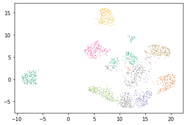

```python
fit = umap.UMAP(min_dist=0.5, spread=2, n_neighbors=nn)
Y = fit.fit_transform(digits.data)
print("Input dimensions:", digits.data.shape)
print("Output dimensions:", Y.shape)
plt.scatter(Y[:,0], Y[:,1], c=digits.target, s=0.1, cmap='Dark2')
```

...I think that might be worse, actually

# Trying Out UMAP with Random Clusters

Starting off with two 2D clusters: $N((5,5),0.5)$ and $N((1,1), 0.5)$

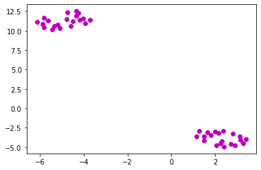

```python
# Create two 2D clusters
X1 = np.random.default_rng(2022).multivariate_normal(mean=[5, 5], cov=(0.5 * np.eye(2)), size=20)
X2 = np.random.default_rng(2022).multivariate_normal(mean=[1, 1], cov=(0.5 * np.eye(2)), size=20)
X = np.vstack((X1, X2))
Y = umap.UMAP().fit_transform(X)
plt.scatter(Y[:,0], Y[:,1], c='m')
```

Plotting $N(\vec{O}, 1)$, $N(t e_1,1)$, and $N(s e_2,1)$, below and then the UMAP result:

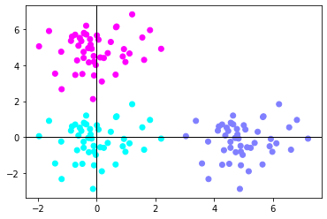

```python
D = 15
t = 5
s = 5
np.identity(D)
X1 = np.random.default_rng(20).multivariate_normal(mean=np.zeros(D), cov=(1 * np.eye(D)), size=50)
X2 = np.random.default_rng(20).multivariate_normal(mean= t * np.identity(D)[0], cov=(1 * np.eye(D)), size=50)
X3 = np.random.default_rng(20).multivariate_normal(mean= s * np.identity(D)[1], cov=(1 * np.eye(D)), size=50)
X = np.vstack((X1, X2, X3))
plt.axvline(x=0, c='k', linewidth=1)
plt.axhline(y=0, c='k', linewidth=1)
plt.scatter(X[:,0], X[:,1],
 c=np.hstack((np.repeat(0,50), np.repeat(1,50), np.repeat(2,50))),
 cmap='cool')
```

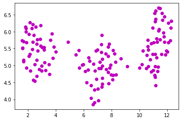

```python
Y = umap.UMAP().fit_transform(X)
plt.scatter(Y[:,0], Y[:,1], c='m')
```

The clusters become less distinct as the dimension increase — they become ambiguous around $D=20$ — maybe because the points are "closer" in some sense when you look at them from higher and higher dimensions?

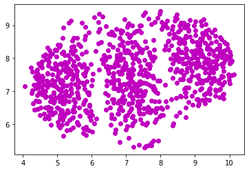

```python
D = 1000
t = 28
s = 28
size = 300
np.identity(D)
X1 = np.random.default_rng(20).multivariate_normal(mean=np.zeros(D), cov=(1 * np.eye(D)), size=size)
X2 = np.random.default_rng(20).multivariate_normal(mean= t * np.identity(D)[0], cov=(1 * np.eye(D)), size=size)
X3 = np.random.default_rng(20).multivariate_normal(mean= s * np.identity(D)[1], cov=(1 * np.eye(D)), size=size)
X = np.vstack((X1, X2, X3))
Y = umap.UMAP().fit_transform(X)
plt.scatter(Y[:,0], Y[:,1], c='m')
```

# Two Cluster Setting

We vary the distances between two clusters to find the threshold UMAP can detect the difference. This varies per dimension.

Dimension: 100, varying the centroids from 0 to 14 units apart

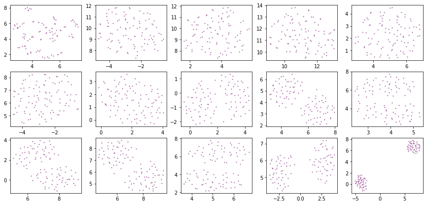

```python
# D = 100, t=1 to t=15
_, axes = plt.subplots(3, 5, figsize=(15, 7))
labels = np.hstack((np.repeat(0, size), np.repeat(1, size)))
scores = np.zeros(15)
for t in range(15):
    D = 100
    size = 50
    np.identity(D)
    X1 = np.random.default_rng(20).multivariate_normal(mean=np.zeros(D), cov=(1 * np.eye(D)), size=size)
    X2 = np.random.default_rng(20).multivariate_normal(mean= t * np.identity(D)[0], cov=(1 * np.eye(D)), size=size)
    X = np.vstack((X1, X2))
    Y = umap.UMAP().fit_transform(X)
    axes[t // 5, t % 5].scatter(Y[:,0], Y[:,1], c='#9B4F96', s=1)
    scores[t] = ASW(Y, labels)
```

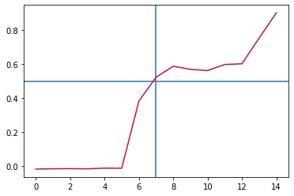

```python
plt.axhline(y=0.5)
t = np.argmax(scores > 0.5)
plt.axvline(x=t)
plt.plot(scores, c='#c41230')
```

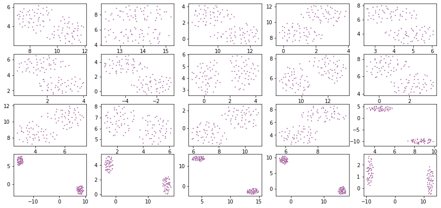

```python
_, axes = plt.subplots(4, 5, figsize=(15, 7))
labels = np.hstack((np.repeat(0, size), np.repeat(1, size)))
scores = np.zeros(20)
for t in range(10, 30):
    D = 300
    size = 50
    np.identity(D)
    X1 = np.random.default_rng(20).multivariate_normal(mean=np.zeros(D), cov=(1 * np.eye(D)), size=size)
    X2 = np.random.default_rng(20).multivariate_normal(mean= t * np.identity(D)[0], cov=(1 * np.eye(D)), size=size)
    X = np.vstack((X1, X2))
    Y = umap.UMAP().fit_transform(X)
    axes[(t-10) // 5, (t-10) % 5].scatter(Y[:,0], Y[:,1], c='#9B4F96', s=1)
    scores[t-10] = ASW(Y, labels)
```

[output not shown]

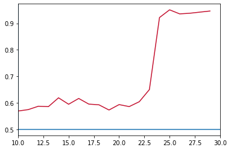

```python
plt.axhline(y=0.5)
t = np.argmax(scores > 0.5)
plt.xlim(10, 30)
plt.plot(np.arange(10, 30), scores, c='#c41230')
```

# Cluster Measures

To quantify how well the dimensionality algorithm represented the clusters, we use the Calinski-Harabasz variance ratio, which compares the ratio between within-cluster and between-cluster variance: $$ \renewcommand{\Ck}{\mathcal{C}_K} \renewcommand{\TCk}{\mathbf{T} _ {\mathcal{C}_K}} \renewcommand{\WCk}{\mathbf{W} _ {\mathcal{C}_K}} \renewcommand{\x}{\mathbf{x}} \renewcommand{\xbar}{\bar{\x}} $$

$$CH(\Ck) = \frac{\mathrm{trace}(\TCk)}{\mathrm{trace}(\WCk)} \times \frac{n-K}{K-1}$$

where between-cluster variance $\TCk$ is $$\TCk = \sum_{j=1}^K n_j (\xbar_j - \xbar) (\xbar_j - \xbar)^T$$ and within-cluster variance $\WCk$ is $$\WCk = \sum_{j=1}^K \sum_{c(i)=j} (\x_i - \xbar_j) (\x_i - \xbar_j)^T$$

This metric is adapted from the objective function for k-means. It assumes a pre-set number of clusters that should be spherical. This doesn't suit all clustering scenarios, but our setup uses Gaussian clusters with a spherical variance matrix, so it's suitable our task. Also, the algorithm has fast implementations, which is suited to our high number of metric calculations.

For example:

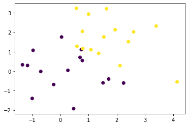

```
17.50122328782498
```

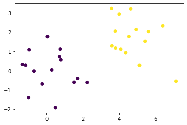

```
79.34075386925672
```

```python
X1 = np.random.default_rng(100).multivariate_normal(
    mean=np.zeros(2), cov=(np.eye(2)), size=15)
X2 = np.random.default_rng(20).multivariate_normal(
    mean=np.array([2, 2]), cov=(np.eye(2)), size=15)
X = np.vstack((X1, X2))
labels = np.hstack((np.repeat(0, 15), np.repeat(1, 15)))
plt.scatter(X[:,0], X[:,1], c=labels)
plt.show()
print(CH(X, labels))

X1 = np.random.default_rng(100).multivariate_normal(
    mean=np.zeros(2), cov=(np.eye(2)), size=15)
X2 = np.random.default_rng(20).multivariate_normal(
    mean=np.array([5, 2]), cov=(np.eye(2)), size=15)
X = np.vstack((X1, X2))
labels = np.hstack((np.repeat(0, 15), np.repeat(1, 15)))
plt.scatter(X[:, 0], X[:, 1], c=labels)
plt.show()
print(CH(X, labels))
```

Larger values of the CH ratio point to better clusterings — clusters that are more internally homogenous and different from each other. The problem here is that it isn't standardized to a certain range, which can make comparisons difficult. Next, we'll try ASW (average sillhoette width):

$$ASW(\mathcal{C}_k) = \frac{1}{n} \sum_{i=1}^n s_i$$$$s_i = \frac{b_i - a_i}{\max(a_i,b_i)}$$$$a_i = \frac{1}{n_k - 1} \sum_{c(j)=k} d(\mathbf{x}_i, \mathbf{x}_j)$$$$b_i = \frac{1}{n_l} \min_{l \ne k} \sum_{c(j)=l} d(\mathbf{x}_i, \mathbf{x}_j)$$

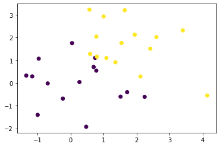

```
0.2877463490205072
```

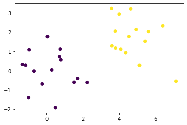

```
0.6198791379016718
```

```python
X1 = np.random.default_rng(100).multivariate_normal(
    mean=np.zeros(2), cov=(np.eye(2)), size=15)
X2 = np.random.default_rng(20).multivariate_normal(
    mean=np.array([2, 2]), cov=(np.eye(2)), size=15)
X = np.vstack((X1, X2))
labels = np.hstack((np.repeat(0, 15), np.repeat(1, 15)))
plt.scatter(X[:, 0], X[:, 1], c=labels)
plt.show()
print(ASW(X, labels))

X1 = np.random.default_rng(100).multivariate_normal(
    mean=np.zeros(2), cov=(np.eye(2)), size=15)
X2 = np.random.default_rng(20).multivariate_normal(
    mean=np.array([5, 2]), cov=(np.eye(2)), size=15)
X = np.vstack((X1, X2))
labels = np.hstack((np.repeat(0, 15), np.repeat(1, 15)))
plt.scatter(X[:, 0], X[:, 1], c=labels)
plt.show()
print(ASW(X, labels))
```

# Plotting Functions

```python
def cluster_test(t=1, s=None, D=1000, size=100):
    # The first cluster is at (0, 0, ...)
    X1 = np.random.default_rng(20).multivariate_normal(mean=np.zeros(D), cov=(1 * np.eye(D)), size=size)
    X2 = np.random.default_rng(20).multivariate_normal(mean= t * np.identity(D)[0], cov=(1 * np.eye(D)), size=size)
    if s is not None:
        print(f"t = {t}, s = {s}")
        X3 = np.random.default_rng(20).multivariate_normal(mean= s * np.identity(D)[1], cov=(1 * np.eye(D)), size=size)
        X = np.vstack((X1, X2, X3))
        labels = np.hstack((np.repeat(0, size), np.repeat(1, size), np.repeat(2, size)))
    else:
        X = np.vstack((X1, X2))
        labels = np.hstack((np.repeat(0, size), np.repeat(1, size)))
    # fix seed for reproducibility
    Y = umap.UMAP(random_state=2022).fit_transform(X)
    score = ASW(Y, labels)
    return (Y, labels, score)

def plot_UMAP(Y, labels=None):
    if labels is not None:
        plt.scatter(Y[:,0], Y[:,1], c=labels)
    else:
        plt.scatter(Y[:,0], Y[:,1])
    plt.show()

def scores_plot(scores, t_range):
    plt.figure(figsize=(6, 5), dpi=80)
    plt.ylim(-1, 1)
    plt.axhline(y=0.5, linestyle='--', c='#4d5051')
    plt.plot(t_range, scores, c='#c41230')
    # plt.axhline(y=0.5)
    plt.title("ASW Score on UMAP Output by Cluster Distance")
    plt.xlabel("Cluster Distance")
    plt.ylabel("Average Silhouette Width")
    plt.show()
    return scores
```

```python
from matplotlib.cm import ScalarMappable


def cluster_tests(t_start=0, t_stop=0, t_step=1, s=None, D=1000, size=100, stop_early=False, plot_scores=False, plotY=None):
    t_range = np.linspace(t_start, t_stop, round((t_stop - t_start)/t_step + 1))

    # print(t_range)
    scores = np.zeros(t_range.size)
    over_threshold = None

    if plotY is not None:
        r, c = plotY
        if r * c != t_range.size:
            raise Exception("Subplot dimensions do not match number of elements")
        fig, axes = plt.subplots(r, c, figsize=(20, 10))


    for i, t in enumerate(t_range):
        Y, labels, score = cluster_test(t, s, D=D, size=size)
        if plotY is not None:
            if c == 1 or r == 1:
                axes[i].scatter(Y[:,0], Y[:,1], c='m')
            else:
                color = BI((score + 0.3)/2)
                axes[i // c, i % c].scatter(Y[:,0], Y[:,1], color=color)
                axes[i // c, i % c].set_title(f"t = {t}")
        scores[i] = score
        # print(score)
        if over_threshold is None and score >= 0.5:
            over_threshold = t
            if stop_early:
                if plot_scores:
                    scores_plot(scores[:i+1], t_range[:i+1])
                return (over_threshold, scores[:i+1])
    if plotY:
        fig.suptitle("UMAP Clusterings By Distance t", fontsize=16)
        plt.subplots_adjust(wspace=0.25, hspace=0.25)
        fig.colorbar(cm.ScalarMappable(norm=mpl.colors.Normalize(-0.3, 1), cmap=BI), ax=axes, location='right')
        plt.show()
    if plot_scores:
        plt.clf()
        scores_plot(scores, t_range)
    # threshold = t_range[np.argmax(scores > 0.5)]
    return (over_threshold, scores)
```

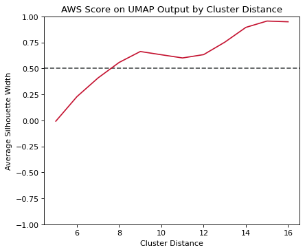

```
(8.0,
 array([-0.00818234,  0.2280554 ,  0.40794522,  0.55711216,  0.66200715,
         0.63079417,  0.60013908,  0.63225007,  0.75171405,  0.89417207,
         0.95501864,  0.94802678]))
```

```python
# cluster_tests(t_start=5, t_stop=15, D=300, plot=True, stop_early=True)

cluster_tests(t_start=5, t_stop=16, D=100, size=30, plot_scores=True)
```

## Optimizing for score

Let's try using some kind of optimization algorithm instead of just iterating up from 0 with increments of 0.1 - it would be accurate and faster way to find the score that means the ASW cluster threshold of 0.5.

```python
def find_threshold(choose_t=True, choose_s=False, set_t = None, D=1000, size=100, asw=0.5, upper_bound=1e2):
    lower_bound = 0
    # define lambda function that's zero when it reaches the threshold of 0.5
    if choose_s and choose_t:  # change both s and t (3 clusters)
        f = lambda t : cluster_test(t=t, s=t, D=D, size=size)[2] - asw
    elif choose_s and not choose_t and set_t is not None:  # set t, change s (3 clusters)
        f = lambda t : cluster_test(t=set_t, s=t, D=D, size=size)[2] - asw
    else: # just change t (2 clusters)
        f = lambda t : cluster_test(t=t, s=None, D=D, size=size)[2] - asw
    # call optimizing algorithm, w/ margin of error 0.1
    return brentq(f, lower_bound, upper_bound, xtol=0.1)
```

# Dimension-Threshold Graphs

## Two Cluster Setting

Now let's try graphing the relationship between dimension and minimum centroid distance to be detected by UMAP (AWS=0.5).

```
Dimension 2, threshold 3.1265207334625633...
Dimension 3, threshold 2.6295270132991027...
Dimension 4, threshold 3.4035902648210734...
Dimension 5, threshold 2.9229195183061556...
Dimension 6, threshold 2.9636389684530475...
Dimension 7, threshold 3.1100451828635576...
Dimension 8, threshold 3.490320078363497...
Dimension 9, threshold 3.248156200063308...
Dimension 10, threshold 3.5655315446266767...
Dimension 11, threshold 3.5842306314607977...
Dimension 12, threshold 3.8577213307152745...
Dimension 13, threshold 3.8701283838357714...
Dimension 14, threshold 3.800407015607024...
Dimension 15, threshold 4.034192213658093...
Dimension 16, threshold 4.082854794260189...
Dimension 17, threshold 4.30427428026175...
Dimension 18, threshold 4.155591559809225...
Dimension 19, threshold 4.7761238099107635...
Dimension 20, threshold 4.597282906931779...
Dimension 21, threshold 4.666666355861286...
Dimension 22, threshold 4.843204769678859...
Dimension 23, threshold 4.922500901316063...
Dimension 24, threshold 5.0199399835592144...
Dimension 25, threshold 5.185372974088914...
Dimension 26, threshold 5.259833544312192...
Dimension 27, threshold 5.178405250419456...
Dimension 28, threshold 5.078383477796321...
Dimension 29, threshold 5.550726528995924...
Dimension 30, threshold 5.441956647336653...
Dimension 31, threshold 5.432437251867018...
Dimension 32, threshold 5.721047830496132...
Dimension 33, threshold 5.732181222199331...
Dimension 34, threshold 5.749470993732638...
Dimension 35, threshold 6.07077513519572...
Dimension 36, threshold 6.158776973349157...
Dimension 37, threshold 5.94379212258021...
Dimension 38, threshold 6.354073786186122...
Dimension 39, threshold 6.203745278873132...
Dimension 40, threshold 6.380920487594623...
Dimension 41, threshold 6.780445998311652...
```

[output cut: 43 more lines]

```
Dimension 85, threshold 6.869063496884358...
Dimension 86, threshold 6.805714050622864...
Dimension 87, threshold 7.394847753450263...
Dimension 88, threshold 6.898071873747576...
Dimension 89, threshold 7.430883428521396...
Dimension 90, threshold 7.2987342438842795...
Dimension 91, threshold 6.481847290238232...
Dimension 92, threshold 6.856972613392357...
Dimension 93, threshold 6.244074700947295...
Dimension 94, threshold 6.586092448791222...
Dimension 95, threshold 6.334164506461391...
Dimension 96, threshold 6.699660886036713...
Dimension 97, threshold 7.0677601174430045...
Dimension 98, threshold 6.8081245914475765...
Dimension 99, threshold 6.887053274850261...
```

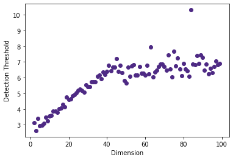

```python
dim_range = np.arange(2, 100, 1)
threshes = np.zeros(dim_range.size)
for i, d in enumerate(dim_range):
    # thresh, scores = cluster_tests(0, 1e6, t_step=0.1, D=d, stop_early=True)
    thresh = find_threshold(D=d)
    # print(thresh,scores)
    # if d % 100 == 0:
    threshes[i] = thresh
    print(f"Dimension {d}, threshold {thresh}...")
    np.savetxt("thresholds.txt", (dim_range, threshes))
plt.scatter(dim_range, threshes, color='#4E2A84')
plt.xlabel("Dimension")
plt.ylabel("Detection Threshold")
plt.savefig("UMAP_dim.png")
np.savetxt("thresholds.txt", (dim_range, threshes))
```

Replotting the graph but with different sizing, aesthetics, etc

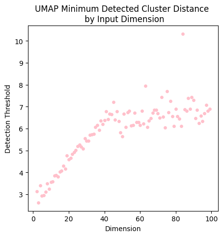

```python
Td, Tt = dim_range, threshes
# Td, Tt = np.genfromtxt("thresholds copy.txt")
plt.figure(figsize=(5, 5), dpi=100)
plt.scatter(Td, Tt, color='pink', s=15)
# plt.plot(Td, Tt, color='#4E2A84', linewidth=0.1)
plt.xlabel("Dimension")
plt.ylabel("Detection Threshold")
plt.title("UMAP Minimum Detected Cluster Distance \n by Input Dimension")
```

## Three Cluster Setting

```python
dim_range = np.arange(3, 1000, 10)
threshes = np.zeros(dim_range.size)
for i, d in enumerate(dim_range):
    thresh = find_threshold(choose_t=True, choose_s=True, D=d)
    # print(thresh,scores)
    # if d % 100 == 0:
    threshes[i] = thresh
    print(f"Dimension {d}, threshold {thresh}...")
    np.savetxt("thresholds3_1_1k_10.txt", (dim_range, threshes))
```

```
t = 0.0, s = 0.0
```

```
t = 100.0, s = 100.0
t = 55.64256241120091, s = 55.64256241120091
t = 27.821281205600457, s = 27.821281205600457
t = 13.910640602800228, s = 13.910640602800228
t = 6.955320301400114, s = 6.955320301400114
t = 3.477660150700057, s = 3.477660150700057
t = 2.744076981902132, s = 2.744076981902132
t = 3.0438710546282017, s = 3.0438710546282017
t = 3.093871054628203, s = 3.093871054628203
Dimension 3, threshold 3.0438710546282017...
t = 0.0, s = 0.0
```

[output not shown]

```
t = 100.0, s = 100.0
t = 53.66179850448236, s = 53.66179850448236
t = 26.83089925224118, s = 26.83089925224118
t = 13.41544962612059, s = 13.41544962612059
t = 6.707724813060295, s = 6.707724813060295
t = 3.3538624065301477, s = 3.3538624065301477
t = 5.742007419616747, s = 5.742007419616747
t = 5.938240789385703, s = 5.938240789385703
t = 5.8882407893857005, s = 5.8882407893857005
t = 5.815124104501224, s = 5.815124104501224
Dimension 33, threshold 5.815124104501224...
t = 0.0, s = 0.0
```

[output not shown]

[output not shown]

[output cut: 330 more lines]

```
t = 100.0, s = 100.0
t = 55.09854198610026, s = 55.09854198610026
t = 27.54927099305013, s = 27.54927099305013
t = 13.774635496525065, s = 13.774635496525065
t = 21.350024608086606, s = 21.350024608086606
t = 19.708648429423853, s = 19.708648429423853
t = 16.74164196297446, s = 16.74164196297446
t = 19.16375410952226, s = 19.16375410952226
t = 17.88106021370471, s = 17.88106021370471
t = 17.831060213704703, s = 17.831060213704703
t = 17.28635108833958, s = 17.28635108833958
t = 17.63184188859313, s = 17.63184188859313
t = 17.681841888593137, s = 17.681841888593137
Dimension 363, threshold 17.63184188859313...
t = 0.0, s = 0.0
```

[output not shown]

[output cut: 104 more lines]

```
t = 100.0, s = 100.0
t = 54.1313589783752, s = 54.1313589783752
t = 27.0656794891876, s = 27.0656794891876
t = 23.23829546394786, s = 23.23829546394786
t = 11.61914773197393, s = 11.61914773197393
t = 21.484528917942413, s = 21.484528917942413
t = 19.64347605615664, s = 19.64347605615664
t = 20.328115411836663, s = 20.328115411836663
t = 20.649693275865896, s = 20.649693275865896
t = 20.760294426048688, s = 20.760294426048688
t = 21.12241167199555, s = 21.12241167199555
t = 20.906111958253955, s = 20.906111958253955
t = 20.9875524004155, s = 20.9875524004155
Dimension 483, threshold 20.906111958253955...
t = 0.0, s = 0.0
```

[output not shown]

[output cut: 267 more lines]

```
Dimension 763, threshold 25.86582666953435...
t = 0.0, s = 0.0
t = 100.0, s = 100.0
t = 54.32822282061661, s = 54.32822282061661
t = 27.164111410308305, s = 27.164111410308305
t = 23.542110143995348, s = 23.542110143995348
t = 26.78527349332182, s = 26.78527349332182
t = 26.41232782680494, s = 26.41232782680494
t = 24.977218985400143, s = 24.977218985400143
t = 25.783629722268802, s = 25.783629722268802
t = 26.089597897319784, s = 26.089597897319784
t = 25.98125114538329, s = 25.98125114538329
t = 26.039597897319773, s = 26.039597897319773
Dimension 773, threshold 26.039597897319773...
t = 0.0, s = 0.0
```

[output not shown]

[output cut: 180 more lines]

```
t = 29.23211308861121, s = 29.23211308861121
t = 29.374838081812676, s = 29.374838081812676
Dimension 983, threshold 29.374838081812676...
t = 0.0, s = 0.0
t = 100.0, s = 100.0
t = 53.31859006930567, s = 53.31859006930567
t = 26.659295034652835, s = 26.659295034652835
t = 41.16326796937919, s = 41.16326796937919
t = 38.694259608738726, s = 38.694259608738726
t = 32.67677732169578, s = 32.67677732169578
t = 29.668036178174308, s = 29.668036178174308
t = 29.854011486512345, s = 29.854011486512345
t = 29.96585653683096, s = 29.96585653683096
t = 29.90401148651236, s = 29.90401148651236
Dimension 993, threshold 29.854011486512345...
```

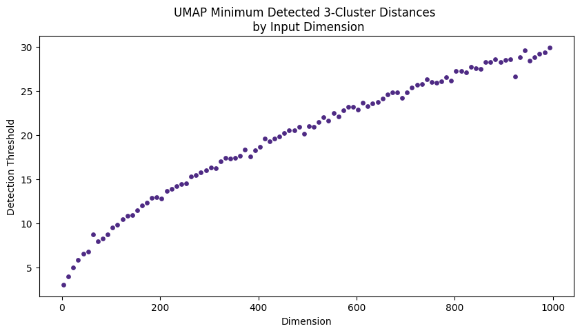

```python
Td, Tt = dim_range, threshes
# Td, Tt = np.genfromtxt("thresholds copy.txt")
plt.figure(figsize=(10, 5), dpi=100)
plt.scatter(Td, Tt, color='#4E2A84', s=15)
# plt.plot(Td, Tt, color='#4E2A84', linewidth=0.1)
plt.xlabel("Dimension")
plt.ylabel("Detection Threshold")
plt.title("UMAP Minimum Detected 3-Cluster Distances \n by Input Dimension")
```

## Comparing 2- and 3- Clusters

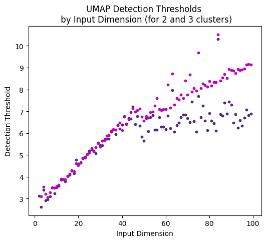

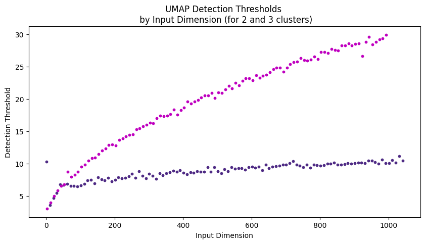

```python
def plot_dimgraph(fname, color='pink', smooth=False):
    Td, Tt = np.genfromtxt(fname)
    plt.xlabel("Input Dimension")
    plt.ylabel("Detection Threshold")
    plt.scatter(Td, Tt, color=color, s=10)
    if smooth:
        min, max = Td[0], Td[-1]
        xnew = np.linspace(min, max, round(max-min)*10)
        spline = make_interp_spline(Td, Tt)
        plt.plot(xnew, spline(xnew), c='m')
    return Td, Tt

    # plt.plot(Td, Tt, color='#4E2A84', linewidth=0.1)


# Plot 1 to 100 graph
plt.figure(figsize=(6, 5), dpi=100)
plt.title("UMAP Detection Thresholds \n by Input Dimension (for 2 and 3 clusters)")
plot_dimgraph("thresholds_1_100_1.txt", '#4E2A84')
plot_dimgraph("thresholds3_1_100_1.txt", 'm')
plt.show()

# Plot 1 to 1000 graph
plt.figure(figsize=(10, 5), dpi=100)
plt.title("UMAP Detection Thresholds \n by Input Dimension (for 2 and 3 clusters)")
plot_dimgraph("thresholds_1_1k_10.txt", '#4E2A84')
plot_dimgraph("thresholds3_1_1k_10.txt", 'm')
plt.show()
```

These aren't bad, but still kind of cluttered. It might be better to fit a smoothed curve (maybe a spline) to each one and plot those instead. First, let's try fitting a curve just for the 2-cluster 100dim dataset.

It looks like `scipy` and `scikit-learn` don't have easy ways of fitting smoothed curves like `ggplot` can. I could try using `plotnine`?

# Modeling the Dimension-Threshold Relationship

```python
# Function for fitting and plotting a transformed linear model
def fit_mod(fname, fn, apply='x', inv_fn=None, plot=True, color='m'):
    if plot:
        Td, Tt = plot_dimgraph(fname)
    else:
        Td, Tt = np.genfromtxt(fname)
    T = Tt.reshape(-1, 1)
    D = Td.reshape(-1, 1)
    Xnew = np.linspace(Td.min(), Td.max(), round(Td.max() - Td.min())*2).reshape(-1, 1)
    if apply == 'x':
        fit = LinReg().fit(fn(D), T)
        print(fit.score(fn(D), T))
        Ynew = fit.predict(fn(Xnew))
    elif apply == 'y' and inv_fn is not None:
        fit = LinReg().fit(D, fn(T))
        print(fit.score(D, fn(T)))
        Ynew = inv_fn(fit.predict(Xnew))
    else:
        raise Exception("Must specify 'x' or 'y' for apply and an inverse function if apply='y'")
    if plot:
        plt.plot(Xnew, Ynew, c=color)

    # get the actual numbers out - return intercept, then coefficient
    return (fit.intercept_[0], fit.coef_[0][0])
```

## Fitting a square root model

$T \sim \sqrt{D}$

```
0.7781007106235502
0.9596151244262725
```

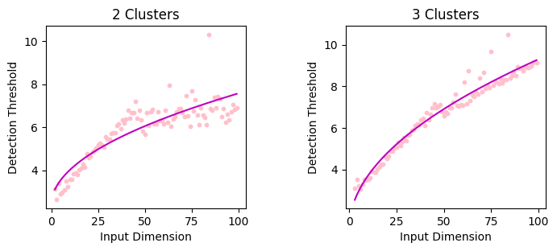

```
0.7939208338976498
0.9965006755604313
```

```
(0.07766219823938059, 0.9379464556369232)
```

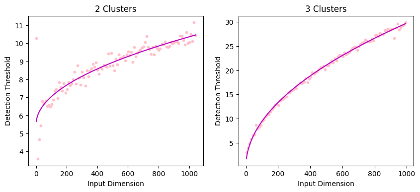

```python
# Plot graphs and fitted lines for first 100 dimensions
plt.figure(figsize=(8, 3), dpi=100)
plt.subplot(121)
plt.title("2 Clusters")
fit_mod('thresholds_1_100_1.txt', lambda x : x**0.5)
plt.subplot(122)
plt.title("3 Clusters")
fit_mod('thresholds3_1_100_1.txt', lambda x : x**0.5)
plt.subplots_adjust(wspace=0.5)
plt.show()

# Plot graphs and fitted lines for first 1000 dimensions
plt.figure(figsize=(10, 4), dpi=100)
plt.subplot(121)
plt.title("2 Clusters")
fit_mod('thresholds_1_1k_10.txt', lambda x : x**0.5)
plt.subplot(122)
plt.title("3 Clusters")
fit_mod('thresholds3_1_1k_10.txt', lambda x : x**0.5)
```

$T^2 \sim D$

```
0.6300451199342515
0.9345355639826407
```

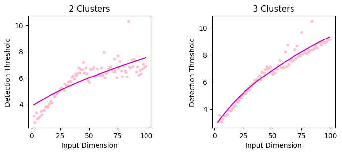

```
0.8203336393612541
0.9952348820055732
```

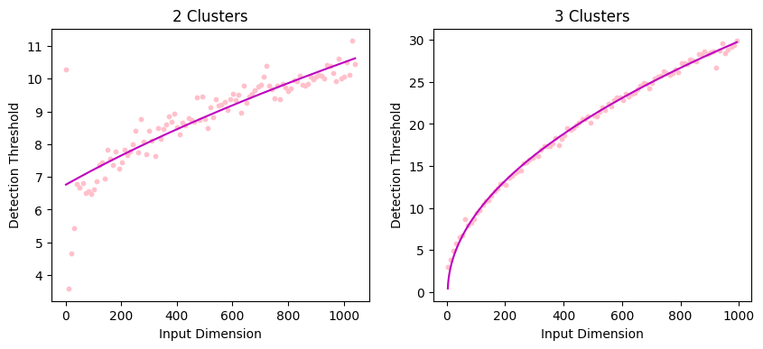

```python
# Plot graphs and fitted lines for first 100 dimensions
plt.figure(figsize=(8, 3), dpi=100)
plt.subplot(121)
plt.title("2 Clusters")
fit_mod('thresholds_1_100_1.txt', lambda y: y**2, apply='y', inv_fn = lambda y: y**0.5)
plt.subplot(122)
plt.title("3 Clusters")
fit_mod('thresholds3_1_100_1.txt', lambda y: y**2, apply='y', inv_fn = lambda y: y**0.5)
plt.subplots_adjust(wspace=0.5)
plt.show()

# Plot graphs and fitted lines for first 1000 dimensions
plt.figure(figsize=(10, 4), dpi=100)
plt.subplot(121)
plt.title("2 Clusters")
fit_mod('thresholds_1_1k_10.txt', lambda y: y **2, apply='y', inv_fn=lambda y: y**0.5)
plt.subplot(122)
plt.title("3 Clusters")
fit_mod('thresholds3_1_1k_10.txt', lambda y: y **2, apply='y', inv_fn=lambda y: y**0.5)
```

Applying the square root to $T$ presents problems when $T < 0$ (when the clusters aren't separated). While this can be fixed with another transformation, the lower accuracy rate for this method combined with this complication suggests a preference for $T \sim \sqrt{D}$.

Some concerns are that the model does noticeably worse for the first 100 dimensions. This is a problem because:

(1) it violates the homoscedasticity assumption, suggesting model misspecification

(2) many real-world input datasets are of the first 100 dimensions, so it is important to model them correctly

$T \sim \log(D)$

```
0.8115109388629443
0.9036387624910984
```

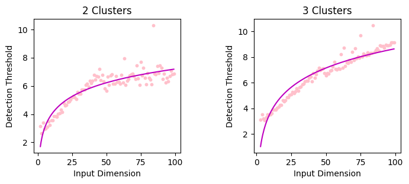

```
0.5674959183047068
0.8718098058283815
```

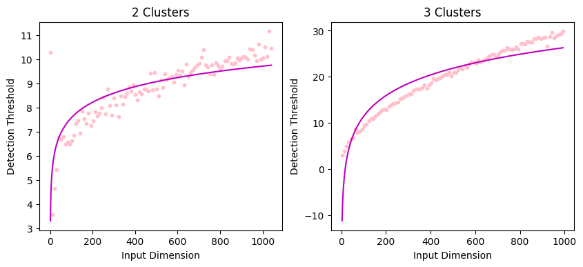

```python
# Plot graphs and fitted lines for first 100 dimensions
plt.figure(figsize=(8, 3), dpi=100)
plt.subplot(121)
plt.title("2 Clusters")
fit_mod('thresholds_1_100_1.txt', lambda x: np.log(x))
plt.subplot(122)
plt.title("3 Clusters")
fit_mod('thresholds3_1_100_1.txt', lambda x: np.log(x))
plt.subplots_adjust(wspace=0.5)
plt.show()

# Plot graphs and fitted lines for first 1000 dimensions
plt.figure(figsize=(10, 4), dpi=100)
plt.subplot(121)
plt.title("2 Clusters")
fit_mod('thresholds_1_1k_10.txt', lambda x: np.log(x))
plt.subplot(122)
plt.title("3 Clusters")
fit_mod('thresholds3_1_1k_10.txt', lambda x: np.log(x))
```

$exp(T) \sim D$

```
0.05308636663168087
0.37102236603932637
```

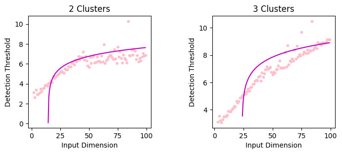

```
0.6618327522142211
0.31756823997795214
```

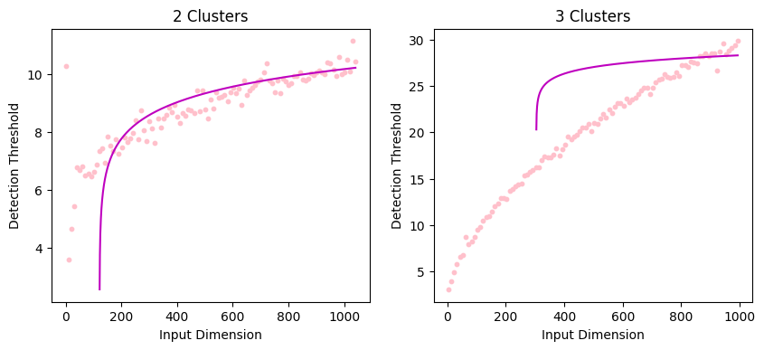

```python
# Plot graphs and fitted lines for first 100 dimensions
plt.figure(figsize=(8, 3), dpi=100)
plt.subplot(121)
plt.title("2 Clusters")
fit_mod('thresholds_1_100_1.txt', np.exp, apply='y', inv_fn=np.log)
plt.subplot(122)
plt.title("3 Clusters")
fit_mod('thresholds3_1_100_1.txt', np.exp, apply='y', inv_fn=np.log)
plt.subplots_adjust(wspace=0.5)
plt.show()

# Plot graphs and fitted lines for first 1000 dimensions
plt.figure(figsize=(10, 4), dpi=100)
plt.subplot(121)
plt.title("2 Clusters")
fit_mod('thresholds_1_1k_10.txt', np.exp, apply='y', inv_fn=np.log)
plt.subplot(122)
plt.title("3 Clusters")
fit_mod('thresholds3_1_1k_10.txt', np.exp, apply='y', inv_fn=np.log)
```

# Varying the ASW Threshold

Since we're going to be drawing lots of dim-thresh curves, let's write a function to make this easier:

```python
def dim_thresh(numrange, asw=0.5, fname=None, plot=True, upper_bound=1e2):
    """numrange = tuple of min, max, step of dimensions \\
    asw = the target ASW score \\
    fname = name of .txt and .png file to save results and graph to \\
    returns the dimension range and thresholds
    """
    dim_range = np.arange(*numrange)
    threshes = np.zeros(dim_range.size)
    for i, d in enumerate(dim_range):
        thresh = find_threshold(D=d, asw=asw, upper_bound=upper_bound)
        threshes[i] = thresh
        if fname is not None:
            np.savetxt(f"{fname}.txt", (dim_range, threshes))
        print(f"Dimension {d}, threshold {thresh}...")
    if plot:
        plt.scatter(dim_range, threshes, color='#4E2A84')
        plt.xlabel("Dimension")
        plt.ylabel("Detection Threshold")
    if fname is not None:
        np.savetxt(f"{fname}.txt", (dim_range, threshes))
        plt.savefig(f"{fname}.png")
    return (dim_range, threshes)
```

Let's see how the dimension-threshold graphs change when we change the minimum cluster separation score from 0.5 to various other values from 0 to 1.

```
0.7939208338976498
(5.507215974285145, 0.153598024373336)
```

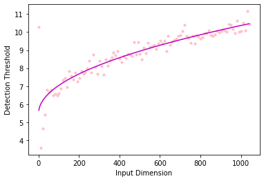

```python
coefs = fit_mod('thresholds_1_1k_10.txt', lambda x: x**0.5, plot=True)
print(coefs)
```

So our dimension-threshold curve model for an average sillhouette width of 0.5 is $T \sim 5.5072 + 0.1536 \sqrt{D}$. Let's see how the curve changes when we set ASW to 0.8, for example:

```
Dimension 2, threshold 5.613750497603059...
Dimension 12, threshold 5.706393371323584...
Dimension 22, threshold 6.050574757243772...
Dimension 32, threshold 6.74166741641923...
Dimension 42, threshold 7.889201729282776...
Dimension 52, threshold 8.834738826814196...
Dimension 62, threshold 9.824628768395186...
Dimension 72, threshold 10.668244929966734...
Dimension 82, threshold 11.534872692496897...
Dimension 92, threshold 12.215431473525387...
```

```
(array([ 2, 12, 22, 32, 42, 52, 62, 72, 82, 92]),
 array([ 5.6137505 ,  5.70639337,  6.05057476,  6.74166742,  7.88920173,
         8.83473883,  9.82462877, 10.66824493, 11.53487269, 12.21543147]))
```

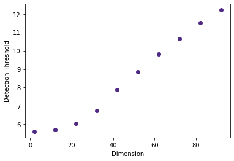

```python
dim_thresh((2, 100, 10), asw=0.8)
```

Now let's see how the dimension-detection curve changes by plotting the above graph for different values of ASW from 0 to 1.

[output not shown]

[output cut: 206 more lines]

```
  4.8520785   5.04480122  5.2030037   5.95454279  5.71669209  5.73208826
  2.02094171  3.29158085  4.55086978  4.82600374  4.73990393  5.24199244
  5.27624384  6.4276941   5.96924415  5.75491619  2.59933135  3.6230844
  4.64296086  5.21024493  5.17182066  5.36160245  5.64459037  6.13189381
  5.83351432  5.93464406  3.12652073  3.85772133  4.84320477  5.72104783
  6.42760129  6.07694433  6.22418903  7.44470339  6.44043562  6.85697261
  3.89761178  4.16965044  5.13280891  6.07291449  7.16788709  8.19844869
  8.93760157  9.85482957 10.91142438  8.46421277  5.18569062  5.16098171
  5.61633312  6.53585112  7.46072725  8.43147868  9.28559193 10.35418945
 11.19406146 11.80124402  5.6137505   5.70639337  6.05057476  6.74166742
  7.88920173  8.83473883  9.82462877 10.66824493 11.53487269 12.21543147
  0.          0.          0.          0.          0.          0.
  0.          0.          0.          0.          0.          0.
  0.          0.          0.          0.          0.          0.
  0.          0.        ]
```

[output not shown]

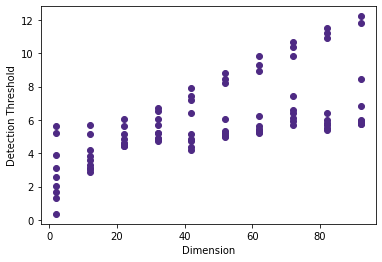

```python
# Plot the 1 to 100 by 10 curve from ASW = 0, 0.1, ..., 1
ASWs = np.linspace(0, 1, 11)
np.repeat(ASWs, 10)
color_labs = np.zeros((ASWs.size))
Y = np.zeros(10*ASWs.size)
for i, asw in enumerate(ASWs):
    D, T = dim_thresh((2, 100, 10), fname=f"{asw}thresholds_1_100_10", asw=asw)
    assert(T.size == 10)
    Y[i*10:i*10+10] = T
    print(Y)
plt.scatter(np.linspace(2, 100, 10), Y, c=color_labs)
```

The upper bound used in the optimization function was 100; apparently, this wasn't high enough of a distance threshold for some values under `ASW=0.9`!